# Model for ART utilisation over time

Oisin Fitzgerald

# Note

The file `scripts/impute.R` needs to be be run before this file. However, knitting this file before running the imputations will result in `scripts/impute.R` being sourced (but you’ll have a long wait).

# Introduction

This document describes the longitudinal modeling of assisted reproductive technology utilisation (ART) as a function of the United Nations produced Human Development Index (HDI) and Gender Inequality Index (GII). Greater details on the rationale for the study can be found in the main manuscript.

# Index Models

## Covariate imputation

Covariates imputed.

### Standard formulation

Model parameter estimates

|  | Estimate | Std.Error | t.value | df | P(>\|t\|) | RIV | FMI |
| --- | --- | --- | --- | --- | --- | --- | --- |
| (Intercept) | 5.465 | 0.100 | 54.884 | 9.785881e+10 | 0.000 | 0.000 | 0.000 |
| time | 0.120 | 0.018 | 6.776 | 8.249891e+08 | 0.000 | 0.000 | 0.000 |
| gii | -0.461 | 0.145 | -3.179 | 6.265658e+04 | 0.001 | 0.041 | 0.040 |
| hdi_un | 1.275 | 0.155 | 8.250 | 1.330004e+05 | 0.000 | 0.028 | 0.027 |

Model parameter 95% CI

|  | 2.5 % | 97.5 % |
| --- | --- | --- |
| (Intercept) | 5.270 | 5.660 |
| time | 0.086 | 0.155 |
| gii | -0.745 | -0.177 |
| hdi_un | 0.972 | 1.578 |

Variance component estimates

|  | Estimate |
| --- | --- |
| Intercept~~Intercept\|country | 0.713 |
| Residual~~Residual | 0.121 |
| ICC\|country | 0.855 |

### Decomposition formulation

Model parameter estimates

|  | Estimate | Std.Error | t.value | df | P(>\|t\|) | RIV | FMI |
| --- | --- | --- | --- | --- | --- | --- | --- |
| (Intercept) | 4.644 | 1.602 | 2.898 | 14318382.0 | 0.004 | 0.003 | 0.003 |
| time_d | 0.005 | 0.010 | 0.465 | 1093544.6 | 0.642 | 0.010 | 0.010 |
| time_m | -0.030 | 0.055 | -0.548 | 198977997.6 | 0.584 | 0.001 | 0.001 |
| gii_d | -1.275 | 1.155 | -1.104 | 24849.6 | 0.270 | 0.067 | 0.063 |
| gii_m | -5.787 | 1.081 | -5.356 | 16114135.4 | 0.000 | 0.002 | 0.002 |
| hdi_d | 17.642 | 2.084 | 8.466 | 11140611.5 | 0.000 | 0.003 | 0.003 |
| hdi_m | 3.713 | 1.593 | 2.332 | 17981907.3 | 0.020 | 0.002 | 0.002 |

Model parameter 95% CI

|  | 2.5 % | 97.5 % |
| --- | --- | --- |
| (Intercept) | 1.503 | 7.784 |
| time_d | -0.015 | 0.025 |
| time_m | -0.138 | 0.077 |
| gii_d | -3.539 | 0.989 |
| gii_m | -7.905 | -3.669 |
| hdi_d | 13.558 | 21.727 |
| hdi_m | 0.592 | 6.835 |

Variance component estimates

|  | Estimate |
| --- | --- |
| Intercept~~Intercept\|country | 0.606 |
| Residual~~Residual | 0.119 |
| ICC\|country | 0.836 |

GII only

Model parameter estimates

|  | Estimate | Std.Error | t.value | df | P(>\|t\|) | RIV | FMI |
| --- | --- | --- | --- | --- | --- | --- | --- |
| (Intercept) | 8.022 | 0.185 | 43.425 | 60702056.74 | 0.000 | 0.001 | 0.001 |
| time | 0.253 | 0.026 | 9.591 | 43801.23 | 0.000 | 0.050 | 0.048 |
| gii_d | -3.409 | 1.191 | -2.863 | 23183.15 | 0.004 | 0.070 | 0.065 |
| gii_m | -8.594 | 0.543 | -15.818 | 16026394.25 | 0.000 | 0.002 | 0.002 |

Model parameter 95% CI

|  | 2.5 % | 97.5 % |
| --- | --- | --- |
| (Intercept) | 7.660 | 8.384 |
| time | 0.202 | 0.305 |
| gii_d | -5.743 | -1.075 |
| gii_m | -9.659 | -7.529 |

Variance component estimates

|  | Estimate |
| --- | --- |
| Intercept~~Intercept\|country | 0.677 |
| Residual~~Residual | 0.132 |
| ICC\|country | 0.837 |

## Covariates and outcome imputation

### Standard formulation

Model parameter estimates

|  | Estimate | Std.Error | t.value | df | P(>\|t\|) | RIV | FMI |
| --- | --- | --- | --- | --- | --- | --- | --- |
| (Intercept) | 5.462 | 0.100 | 54.364 | 415010.185 | 0.000 | 0.016 | 0.015 |
| time | 0.132 | 0.018 | 7.171 | 3335.636 | 0.000 | 0.208 | 0.173 |
| gii | -0.540 | 0.156 | -3.470 | 407.355 | 0.001 | 0.972 | 0.495 |
| hdi_un | 1.232 | 0.170 | 7.259 | 467.015 | 0.000 | 0.853 | 0.463 |

Model parameter 95% CI

|  | 2.5 % | 97.5 % |
| --- | --- | --- |
| (Intercept) | 5.265 | 5.659 |
| time | 0.096 | 0.168 |
| gii | -0.846 | -0.234 |
| hdi_un | 0.898 | 1.565 |

Variance component estimates

|  | Estimate |
| --- | --- |
| Intercept~~Intercept\|country | 0.726 |
| Residual~~Residual | 0.127 |
| ICC\|country | 0.851 |

### Decomposition formulation

GII + HDI

Model parameter estimates

|  | Estimate | Std.Error | t.value | df | P(>\|t\|) | RIV | FMI |
| --- | --- | --- | --- | --- | --- | --- | --- |
| (Intercept) | 4.682 | 1.472 | 3.181 | 58124.947 | 0.001 | 0.043 | 0.041 |
| time | 0.047 | 0.037 | 1.276 | 831.142 | 0.202 | 0.527 | 0.347 |
| gii_d | -2.377 | 1.085 | -2.191 | 313.135 | 0.029 | 1.285 | 0.565 |
| gii_m | -6.446 | 1.089 | -5.921 | 91766.892 | 0.000 | 0.034 | 0.033 |
| hdi_d | 14.627 | 2.042 | 7.163 | 479.592 | 0.000 | 0.833 | 0.457 |
| hdi_m | 3.552 | 1.539 | 2.308 | 55640.511 | 0.021 | 0.044 | 0.042 |

Model parameter 95% CI

|  | 2.5 % | 97.5 % |
| --- | --- | --- |
| (Intercept) | 1.798 | 7.567 |
| time | -0.025 | 0.118 |
| gii_d | -4.511 | -0.242 |
| gii_m | -8.580 | -4.312 |
| hdi_d | 10.615 | 18.640 |
| hdi_m | 0.536 | 6.567 |

Variance component estimates

|  | Estimate |
| --- | --- |
| Intercept~~Intercept\|country | 0.604 |
| Residual~~Residual | 0.125 |
| ICC\|country | 0.828 |

GII only

Model parameter estimates

|  | Estimate | Std.Error | t.value | df | P(>\|t\|) | RIV | FMI |
| --- | --- | --- | --- | --- | --- | --- | --- |
| (Intercept) | 8.057 | 0.180 | 44.853 | 629572.318 | 0 | 0.013 | 0.013 |
| time | 0.271 | 0.027 | 10.205 | 443.003 | 0 | 0.897 | 0.475 |
| gii_d | -4.336 | 1.060 | -4.090 | 347.317 | 0 | 1.145 | 0.537 |
| gii_m | -8.688 | 0.517 | -16.814 | 92386.614 | 0 | 0.034 | 0.033 |

Model parameter 95% CI

|  | 2.5 % | 97.5 % |
| --- | --- | --- |
| (Intercept) | 7.705 | 8.409 |
| time | 0.219 | 0.324 |
| gii_d | -6.421 | -2.251 |
| gii_m | -9.700 | -7.675 |

Variance component estimates

|  | Estimate |
| --- | --- |
| Intercept~~Intercept\|country | 0.642 |
| Residual~~Residual | 0.138 |
| ICC\|country | 0.823 |

# Component Models

## Covariate imputation

### Standard formulation - no shrinkage on fixed effects

#### Unscaled

Model parameter estimates

|  | Estimate | Std.Error | t.value | df | P(>\|t\|) | RIV | FMI |
| --- | --- | --- | --- | --- | --- | --- | --- |
| (Intercept) | -5.622 | 2.075 | -2.709 | 102925.232 | 0.007 | 0.032 | 0.031 |
| time | 0.069 | 0.026 | 2.610 | 740834.673 | 0.009 | 0.012 | 0.012 |
| ln_abr | 0.069 | 0.130 | 0.531 | 348035.002 | 0.595 | 0.017 | 0.017 |
| ln_mmr | -0.342 | 0.110 | -3.104 | 1992058.184 | 0.002 | 0.007 | 0.007 |
| women_parl_wb | 1.177 | 0.390 | 3.015 | 81677.057 | 0.003 | 0.036 | 0.035 |
| sch_gap | 0.949 | 0.779 | 1.218 | 418.674 | 0.224 | 0.947 | 0.489 |
| mean_sch_un | 0.038 | 0.043 | 0.901 | 200064.108 | 0.368 | 0.023 | 0.022 |
| lab_gap_wb | 1.110 | 0.800 | 1.388 | 64848.505 | 0.165 | 0.041 | 0.039 |
| life_expect_wb | -0.018 | 0.020 | -0.888 | 1865510.130 | 0.375 | 0.007 | 0.007 |
| ln_gni_wb | 1.307 | 0.144 | 9.086 | 357558.199 | 0.000 | 0.017 | 0.017 |

Model parameter 95% CI

|  | 2.5 % | 97.5 % |
| --- | --- | --- |
| (Intercept) | -9.689 | -1.554 |
| time | 0.017 | 0.120 |
| ln_abr | -0.185 | 0.323 |
| ln_mmr | -0.557 | -0.126 |
| women_parl_wb | 0.412 | 1.942 |
| sch_gap | -0.583 | 2.480 |
| mean_sch_un | -0.045 | 0.122 |
| lab_gap_wb | -0.458 | 2.678 |
| life_expect_wb | -0.058 | 0.022 |
| ln_gni_wb | 1.025 | 1.590 |

Variance component estimates

|  | Estimate |
| --- | --- |
| Intercept~~Intercept\|country | 0.740 |
| Residual~~Residual | 0.113 |
| ICC\|country | 0.867 |

### Scaled

Model parameter estimates

|  | Estimate | Std.Error | t.value | df | P(>\|t\|) | RIV | FMI |
| --- | --- | --- | --- | --- | --- | --- | --- |
| time1 | 0.065 | 0.028 | 2.313 | 984682.221 | 0.021 | 0.010 | 0.010 |
| ln_abr1 | 0.116 | 0.140 | 0.825 | 412951.497 | 0.409 | 0.016 | 0.015 |
| ln_mmr1 | -0.477 | 0.178 | -2.684 | 2382762.126 | 0.007 | 0.006 | 0.006 |
| women_parl_wb1 | 0.125 | 0.041 | 3.043 | 84897.507 | 0.002 | 0.035 | 0.034 |
| sch_gap1 | 0.060 | 0.055 | 1.076 | 414.779 | 0.283 | 0.955 | 0.491 |
| lab_gap_wb1 | 0.152 | 0.086 | 1.766 | 86928.821 | 0.077 | 0.035 | 0.034 |
| mean_sch_un1 | 0.110 | 0.121 | 0.905 | 242761.855 | 0.366 | 0.021 | 0.020 |
| life_expect_wb1 | -0.099 | 0.176 | -0.564 | 2600228.033 | 0.572 | 0.006 | 0.006 |
| ln_gni_wb1 | 1.276 | 0.142 | 8.959 | 388966.033 | 0.000 | 0.016 | 0.016 |

Model parameter 95% CI

|  | 2.5 % | 97.5 % |
| --- | --- | --- |
| time1 | 0.010 | 0.120 |
| ln_abr1 | -0.159 | 0.391 |
| ln_mmr1 | -0.826 | -0.129 |
| women_parl_wb1 | 0.044 | 0.205 |
| sch_gap1 | -0.049 | 0.169 |
| lab_gap_wb1 | -0.017 | 0.320 |
| mean_sch_un1 | -0.128 | 0.348 |
| life_expect_wb1 | -0.444 | 0.246 |
| ln_gni_wb1 | 0.997 | 1.555 |

Variance component estimates

|  | Estimate |
| --- | --- |
| Intercept~~Intercept\|country | 1.037 |
| Residual~~Residual | 0.112 |
| ICC\|country | 0.902 |

### Standard formulation - L2 shrinkage on fixed effects

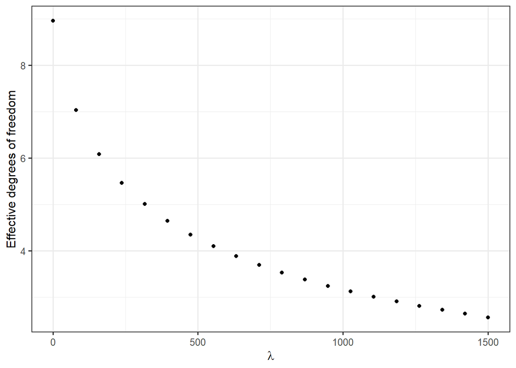

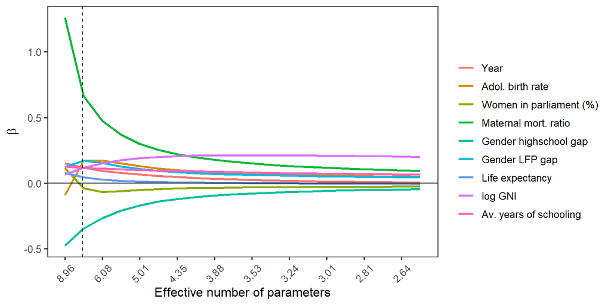

Only consider scaled, else interpretation confusing.

**These results are for the component analysis main model**

Model parameter estimates

|  | Estimate | Std.Error | t.value | df | P(>\|t\|) | RIV | FMI |
| --- | --- | --- | --- | --- | --- | --- | --- |
| time1 | 0.117 | 0.028 | 4.159 | 8.721590e+06 | 0.000 | 0.003 | 0.003 |
| ln_abr1 | -0.039 | 0.140 | -0.279 | 5.696057e+07 | 0.781 | 0.001 | 0.001 |
| women_parl_wb1 | 0.114 | 0.041 | 2.742 | 1.812675e+05 | 0.006 | 0.024 | 0.023 |
| ln_mmr1 | -0.349 | 0.179 | -1.954 | 5.845900e+09 | 0.051 | 0.000 | 0.000 |
| sch_gap1 | 0.027 | 0.053 | 0.513 | 5.372690e+02 | 0.608 | 0.752 | 0.431 |
| lab_gap_wb1 | 0.123 | 0.086 | 1.434 | 4.575563e+05 | 0.152 | 0.015 | 0.015 |
| life_expect_wb1 | 0.168 | 0.176 | 0.955 | 1.057503e+09 | 0.340 | 0.000 | 0.000 |
| ln_gni_wb1 | 0.674 | 0.143 | 4.716 | 1.035129e+07 | 0.000 | 0.003 | 0.003 |
| mean_sch_un1 | 0.168 | 0.121 | 1.389 | 6.185557e+06 | 0.165 | 0.004 | 0.004 |

Model parameter 95% CI

|  | 2.5 % | 97.5 % |
| --- | --- | --- |
| time1 | 0.062 | 0.172 |
| ln_abr1 | -0.314 | 0.236 |
| women_parl_wb1 | 0.032 | 0.195 |
| ln_mmr1 | -0.699 | 0.001 |
| sch_gap1 | -0.077 | 0.132 |
| lab_gap_wb1 | -0.045 | 0.291 |
| life_expect_wb1 | -0.177 | 0.513 |
| ln_gni_wb1 | 0.394 | 0.954 |
| mean_sch_un1 | -0.069 | 0.406 |

## Covariates and outcome imputation

### Standard formulation - L2 shrinkage on fixed effects

**These results are for the component analysis (sensitivity analysis, full imputation)**

Model parameter estimates

|  | Estimate | Std.Error | t.value | df | P(>\|t\|) | RIV | FMI |
| --- | --- | --- | --- | --- | --- | --- | --- |
| time1 | 0.120 | 0.025 | 4.844 | 7123.958 | 0.000 | 0.134 | 0.118 |
| ln_abr1 | -0.013 | 0.117 | -0.107 | 10723.877 | 0.915 | 0.106 | 0.096 |
| women_parl_wb1 | 0.120 | 0.040 | 2.995 | 1073.638 | 0.003 | 0.436 | 0.305 |
| ln_mmr1 | -0.416 | 0.130 | -3.208 | 6255.639 | 0.001 | 0.144 | 0.126 |
| sch_gap1 | 0.068 | 0.059 | 1.158 | 192.805 | 0.248 | 2.528 | 0.719 |
| lab_gap_wb1 | 0.106 | 0.073 | 1.458 | 2401.639 | 0.145 | 0.255 | 0.204 |
| life_expect_wb1 | 0.111 | 0.128 | 0.868 | 2981.473 | 0.386 | 0.223 | 0.183 |
| ln_gni_wb1 | 0.825 | 0.118 | 7.004 | 4054.982 | 0.000 | 0.185 | 0.157 |
| mean_sch_un1 | 0.182 | 0.099 | 1.841 | 8384.747 | 0.066 | 0.122 | 0.109 |

Model parameter 95% CI

|  | 2.5 % | 97.5 % |
| --- | --- | --- |
| time1 | 0.071 | 0.168 |
| ln_abr1 | -0.242 | 0.216 |
| women_parl_wb1 | 0.041 | 0.199 |
| ln_mmr1 | -0.671 | -0.162 |
| sch_gap1 | -0.048 | 0.185 |
| lab_gap_wb1 | -0.037 | 0.249 |
| life_expect_wb1 | -0.140 | 0.362 |
| ln_gni_wb1 | 0.594 | 1.055 |
| mean_sch_un1 | -0.012 | 0.377 |